# Titanic Analyses iter 1

My first attempt at data science process Identify objectives > Data collection and understanding > Data preparation > Data Modeling > Evaluate Model > Conclusions and review

Identify Objecticces 1) Implment Data science flow on Titanic DS set to predict survival 2) analyze results and review what can be improved / what you did wrong

DATA COLLECTION AND UNDERSTANDING Load Data

```r
train <- read.csv("train.csv", stringsAsFactors = F)
str(train)
```

```
'data.frame':   891 obs. of  12 variables:
 $ PassengerId: int  1 2 3 4 5 6 7 8 9 10 ...
 $ Survived   : int  0 1 1 1 0 0 0 0 1 1 ...
 $ Pclass     : int  3 1 3 1 3 3 1 3 3 2 ...
 $ Name       : chr  "Braund, Mr. Owen Harris" "Cumings, Mrs. John Bradley (Florence Briggs Thayer)" "Heikkinen, Miss. Laina" "Futrelle, Mrs. Jacques Heath (Lily May Peel)" ...
 $ Sex        : chr  "male" "female" "female" "female" ...
 $ Age        : num  22 38 26 35 35 NA 54 2 27 14 ...
 $ SibSp      : int  1 1 0 1 0 0 0 3 0 1 ...
 $ Parch      : int  0 0 0 0 0 0 0 1 2 0 ...
 $ Ticket     : chr  "A/5 21171" "PC 17599" "STON/O2. 3101282" "113803" ...
 $ Fare       : num  7.25 71.28 7.92 53.1 8.05 ...
 $ Cabin      : chr  "" "C85" "" "C123" ...
 $ Embarked   : chr  "S" "C" "S" "S" ...
```

```r
test <- read.csv("test.csv", stringsAsFactors = F)
str(test)
```

```
'data.frame':   418 obs. of  11 variables:
 $ PassengerId: int  892 893 894 895 896 897 898 899 900 901 ...
 $ Pclass     : int  3 3 2 3 3 3 3 2 3 3 ...
 $ Name       : chr  "Kelly, Mr. James" "Wilkes, Mrs. James (Ellen Needs)" "Myles, Mr. Thomas Francis" "Wirz, Mr. Albert" ...
 $ Sex        : chr  "male" "female" "male" "male" ...
 $ Age        : num  34.5 47 62 27 22 14 30 26 18 21 ...
 $ SibSp      : int  0 1 0 0 1 0 0 1 0 2 ...
 $ Parch      : int  0 0 0 0 1 0 0 1 0 0 ...
 $ Ticket     : chr  "330911" "363272" "240276" "315154" ...
 $ Fare       : num  7.83 7 9.69 8.66 12.29 ...
 $ Cabin      : chr  "" "" "" "" ...
 $ Embarked   : chr  "Q" "S" "Q" "S" ...
```

Combine data for easier processing

```r
all <- rbind(train[names(train) != "Survived"], test)
str(all)
```

```
'data.frame':   1309 obs. of  11 variables:
 $ PassengerId: int  1 2 3 4 5 6 7 8 9 10 ...
 $ Pclass     : int  3 1 3 1 3 3 1 3 3 2 ...
 $ Name       : chr  "Braund, Mr. Owen Harris" "Cumings, Mrs. John Bradley (Florence Briggs Thayer)" "Heikkinen, Miss. Laina" "Futrelle, Mrs. Jacques Heath (Lily May Peel)" ...
 $ Sex        : chr  "male" "female" "female" "female" ...
 $ Age        : num  22 38 26 35 35 NA 54 2 27 14 ...
 $ SibSp      : int  1 1 0 1 0 0 0 3 0 1 ...
 $ Parch      : int  0 0 0 0 0 0 0 1 2 0 ...
 $ Ticket     : chr  "A/5 21171" "PC 17599" "STON/O2. 3101282" "113803" ...
 $ Fare       : num  7.25 71.28 7.92 53.1 8.05 ...
 $ Cabin      : chr  "" "C85" "" "C123" ...
 $ Embarked   : chr  "S" "C" "S" "S" ...
```

Lets visualize some of the data in particular Pclass, sex, and age factored by survival rate

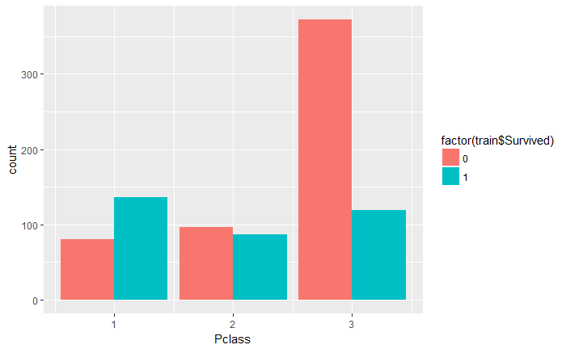

```r
library(ggplot2)
library(gridExtra)
ggplot(train, aes(Pclass)) + geom_bar(position = "dodge", aes(fill = factor(train$Survived)))
```

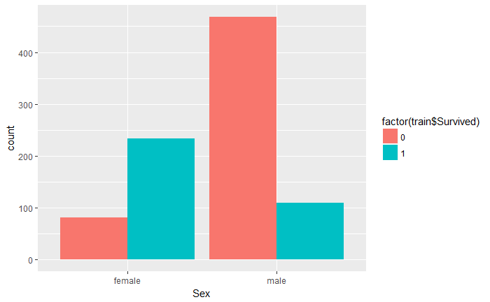

```r
ggplot(train, aes(Sex)) + geom_bar(position = "dodge", aes(fill = factor(train$Survived)))
```

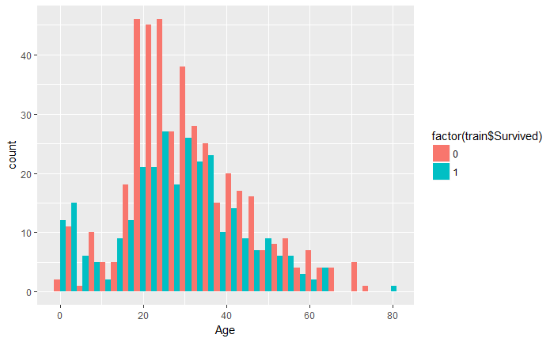

```r
ggplot(train, aes(Age)) + geom_histogram(position = "dodge", aes(fill = factor(train$Survived)))
```

DATA PREPARATION

Lets look for missing values using summary (this only takes care of Numericc Data)

```r
summary(all)
```

```
  PassengerId       Pclass          Name               Sex                 Age            SibSp            Parch          Ticket               Fare            Cabin             Embarked
 Min.   :   1   Min.   :1.000   Length:1309        Length:1309        Min.   : 0.17   Min.   :0.0000   Min.   :0.000   Length:1309        Min.   :  0.000   Length:1309        Length:1309
 1st Qu.: 328   1st Qu.:2.000   Class :character   Class :character   1st Qu.:21.00   1st Qu.:0.0000   1st Qu.:0.000   Class :character   1st Qu.:  7.896   Class :character   Class :character
 Median : 655   Median :3.000   Mode  :character   Mode  :character   Median :28.00   Median :0.0000   Median :0.000   Mode  :character   Median : 14.454   Mode  :character   Mode  :character
 Mean   : 655   Mean   :2.295                                         Mean   :29.88   Mean   :0.4989   Mean   :0.385                      Mean   : 33.295
 3rd Qu.: 982   3rd Qu.:3.000                                         3rd Qu.:39.00   3rd Qu.:1.0000   3rd Qu.:0.000                      3rd Qu.: 31.275
 Max.   :1309   Max.   :3.000                                         Max.   :80.00   Max.   :8.0000   Max.   :9.000                      Max.   :512.329
                                                                      NA's   :263                                                         NA's   :1
```

Age has 263 NA’s, Fare has 1 NA. This takes care of numeric data.

For chr data lets sum up all “” values (“” seems to be the default string value for missing character values)

```r
Chr_cols <- c("Name", "Sex", "Ticket", "Cabin", "Embarked")
for(i in Chr_cols){

        print(paste(i, ": ", sum(all[i] == "")))

}
```

```
[1] "Name :  0"
[1] "Sex :  0"
[1] "Ticket :  0"
[1] "Cabin :  1014"
[1] "Embarked :  2"
```

Embarked has 2 missing values and Cabin has 1014 missing values

The easiest values to replace are Embarked and Fare. We’ll replace Embarked and Fare with the median for each

```r
all$Embarked[all$Embarked == ""] <- "S"
all$Fare[is.na(all$Fare)] <- 14.454
summary(all)
```

```
  PassengerId       Pclass          Name               Sex                 Age            SibSp            Parch          Ticket               Fare            Cabin             Embarked
 Min.   :   1   Min.   :1.000   Length:1309        Length:1309        Min.   : 0.17   Min.   :0.0000   Min.   :0.000   Length:1309        Min.   :  0.000   Length:1309        Length:1309
 1st Qu.: 328   1st Qu.:2.000   Class :character   Class :character   1st Qu.:21.00   1st Qu.:0.0000   1st Qu.:0.000   Class :character   1st Qu.:  7.896   Class :character   Class :character
 Median : 655   Median :3.000   Mode  :character   Mode  :character   Median :28.00   Median :0.0000   Median :0.000   Mode  :character   Median : 14.454   Mode  :character   Mode  :character
 Mean   : 655   Mean   :2.295                                         Mean   :29.88   Mean   :0.4989   Mean   :0.385                      Mean   : 33.281
 3rd Qu.: 982   3rd Qu.:3.000                                         3rd Qu.:39.00   3rd Qu.:1.0000   3rd Qu.:0.000                      3rd Qu.: 31.275
 Max.   :1309   Max.   :3.000                                         Max.   :80.00   Max.   :8.0000   Max.   :9.000                      Max.   :512.329
                                                                      NA's   :263
```

Now we want to attempt our first machine learning algorithm using the cleaned data. I will be using Pclass, Sex, Embarked, and Age for my first attempt First I need to make the data numeric / factors

```r
factor_col_names <- c("Pclass", "Sex", "Embarked")
for (i in factor_col_names){
        new_col_name <- paste("factor_", i)
        all[,new_col_name] <- factor(all[,i])
}
summary(all)
```

```
  PassengerId       Pclass          Name               Sex                 Age            SibSp            Parch          Ticket               Fare            Cabin             Embarked         factor_ Pclass
 Min.   :   1   Min.   :1.000   Length:1309        Length:1309        Min.   : 0.17   Min.   :0.0000   Min.   :0.000   Length:1309        Min.   :  0.000   Length:1309        Length:1309        1:323
 1st Qu.: 328   1st Qu.:2.000   Class :character   Class :character   1st Qu.:21.00   1st Qu.:0.0000   1st Qu.:0.000   Class :character   1st Qu.:  7.896   Class :character   Class :character   2:277
 Median : 655   Median :3.000   Mode  :character   Mode  :character   Median :28.00   Median :0.0000   Median :0.000   Mode  :character   Median : 14.454   Mode  :character   Mode  :character   3:709
 Mean   : 655   Mean   :2.295                                         Mean   :29.88   Mean   :0.4989   Mean   :0.385                      Mean   : 33.281
 3rd Qu.: 982   3rd Qu.:3.000                                         3rd Qu.:39.00   3rd Qu.:1.0000   3rd Qu.:0.000                      3rd Qu.: 31.275
 Max.   :1309   Max.   :3.000                                         Max.   :80.00   Max.   :8.0000   Max.   :9.000                      Max.   :512.329
                                                                      NA's   :263
 factor_ Sex  factor_ Embarked
 female:466   C:270
 male  :843   Q:123
              S:916
```

```r
str(all)
```

```
'data.frame':   1309 obs. of  14 variables:
 $ PassengerId     : int  1 2 3 4 5 6 7 8 9 10 ...
 $ Pclass          : int  3 1 3 1 3 3 1 3 3 2 ...
 $ Name            : chr  "Braund, Mr. Owen Harris" "Cumings, Mrs. John Bradley (Florence Briggs Thayer)" "Heikkinen, Miss. Laina" "Futrelle, Mrs. Jacques Heath (Lily May Peel)" ...
 $ Sex             : chr  "male" "female" "female" "female" ...
 $ Age             : num  22 38 26 35 35 NA 54 2 27 14 ...
 $ SibSp           : int  1 1 0 1 0 0 0 3 0 1 ...
 $ Parch           : int  0 0 0 0 0 0 0 1 2 0 ...
 $ Ticket          : chr  "A/5 21171" "PC 17599" "STON/O2. 3101282" "113803" ...
 $ Fare            : num  7.25 71.28 7.92 53.1 8.05 ...
 $ Cabin           : chr  "" "C85" "" "C123" ...
 $ Embarked        : chr  "S" "C" "S" "S" ...
 $ factor_ Pclass  : Factor w/ 3 levels "1","2","3": 3 1 3 1 3 3 1 3 3 2 ...
 $ factor_ Sex     : Factor w/ 2 levels "female","male": 2 1 1 1 2 2 2 2 1 1 ...
 $ factor_ Embarked: Factor w/ 3 levels "C","Q","S": 3 1 3 3 3 2 3 3 3 1 ...
```

DATA MODELING

Create Xtrain, Ytrain and Xtest in prepartion for glm

```r
train_names <- c("factor_ Pclass", "factor_ Sex")
Xtrain <- all[1:891, train_names]
Xtrain$Survived <- factor(train[,"Survived"])
Xtest <- all[892:1309, train_names]
model <- glm(Survived ~ ., data = Xtrain, family = binomial)
model_test <-factor(ifelse(predict(model, newdata = Xtrain[train_names]) > 0.5,1,0))
summary(model)
```

```
Call:
glm(formula = Survived ~ ., family = binomial, data = Xtrain)

Deviance Residuals:
    Min       1Q   Median       3Q      Max
-2.1877  -0.7312  -0.4476   0.6465   2.1681

Coefficients:
                  Estimate Std. Error z value Pr(>|z|)
(Intercept)         2.2971     0.2190  10.490  < 2e-16 ***
`factor_ Pclass`2  -0.8380     0.2447  -3.424 0.000618 ***
`factor_ Pclass`3  -1.9055     0.2141  -8.898  < 2e-16 ***
`factor_ Sex`male  -2.6419     0.1841 -14.351  < 2e-16 ***
---
Signif. codes:  0 ‘***’ 0.001 ‘**’ 0.01 ‘*’ 0.05 ‘.’ 0.1 ‘ ’ 1

(Dispersion parameter for binomial family taken to be 1)

    Null deviance: 1186.66  on 890  degrees of freedom
Residual deviance:  826.89  on 887  degrees of freedom
AIC: 834.89

Number of Fisher Scoring iterations: 4
```

```r
confusionMatrix(Xtrain$Survived, model_test)
```

```
Confusion Matrix and Statistics

          Reference
Prediction   0   1
         0 540   9
         1 181 161

               Accuracy : 0.7868
                 95% CI : (0.7584, 0.8132)
    No Information Rate : 0.8092
    P-Value [Acc > NIR] : 0.9583

                  Kappa : 0.502
 Mcnemar's Test P-Value : <2e-16

            Sensitivity : 0.7490
            Specificity : 0.9471
         Pos Pred Value : 0.9836
         Neg Pred Value : 0.4708
             Prevalence : 0.8092
         Detection Rate : 0.6061
   Detection Prevalence : 0.6162
      Balanced Accuracy : 0.8480

       'Positive' Class : 0
```

```r
compare <- data.frame(Model = model_test, Actual = factor(Xtrain$Survived))
head(compare)
```

|  | Model | Actual |
| --- | --- | --- |
| 1 | 0 | 0 |
| 2 | 1 | 1 |
| 3 | 0 | 1 |
| 4 | 1 | 1 |
| 5 | 0 | 0 |
| 6 | 0 | 0 |

CONCLUSIONS AND REVIEW

Even with only a few features we were able to achieve ~ 78% accuracy rate

Clearly we can use more features and there is more data to look at

Furthermore we did not create either a test/validation/test set so our data is most likeley over trained

we did not look at any regularization parameters or try to identify bias/variance

Other ML algorithms should also be considered (SVM, decision trees)